# Parameter tuning caret

Carlos Santillan

August 8, 2017

## Caret model tuning

### Carlos Santillan

Senior Software Engineer

Bentley Systems Inc

https://www.linkedin.com/in/carlos-santillan/

https://csantill.github.io/RTuningModelParameters/

```r
# load the library
#install.packages(c("dplyr","e1071", "caret", "doSNOW", "ipred", "xgboost","rattle","rpart.plot","mlbench"))
library(mlbench)
library(plyr); library(dplyr)
library(caret)
library(rattle)                 # Fancy tree plot
library(rpart.plot)
library(dplyr)
library(parallel)
library(rpart)
reset.seed <- function()
{
  # ensure results are repeatable
  set.seed(1337)
}
```

## caret (Classification And Regression Training)

The caret package contains set of functions to streamline model training for Regression and Classification.

- Standard Interface for Modeling and Prediction
- Simplify Model tuning
- Data splitting
- Feature selection
- Evaluate models
- Paralell processing

### Models Supported

caret supports hundreds of predictive models, and provides facilities for adding your own models to take advantage of the caret infrastructure.

You can get a list of models supported by caret

https://topepo.github.io/caret/available-models.html

```r
names(getModelInfo())
```

```
##   [1] "ada"                 "AdaBag"              "AdaBoost.M1"
##   [4] "adaboost"            "amdai"               "ANFIS"
##   [7] "avNNet"              "awnb"                "awtan"
##  [10] "bag"                 "bagEarth"            "bagEarthGCV"
##  [13] "bagFDA"              "bagFDAGCV"           "bam"
##  [16] "bartMachine"         "bayesglm"            "binda"
##  [19] "blackboost"          "blasso"              "blassoAveraged"
##  [22] "bridge"              "brnn"                "BstLm"
##  [25] "bstSm"               "bstTree"             "C5.0"
##  [28] "C5.0Cost"            "C5.0Rules"           "C5.0Tree"
##  [31] "cforest"             "chaid"               "CSimca"
##  [34] "ctree"               "ctree2"              "cubist"
##  [37] "dda"                 "deepboost"           "DENFIS"
##  [40] "dnn"                 "dwdLinear"           "dwdPoly"
##  [43] "dwdRadial"           "earth"               "elm"
```

[output cut: 63 more lines]

## Tunable parameters for a model

The tunable parameters for a given model

CART Classification and Regression Tree

```r
modelLookup("rpart2")
```

```
##    model parameter          label forReg forClass probModel
## 1 rpart2  maxdepth Max Tree Depth   TRUE     TRUE      TRUE
```

xgboost eXtreme Gradient Boosting

https://github.com/dmlc/xgboost

```r
modelLookup("xgbTree")
```

```
##     model        parameter                          label forReg forClass
## 1 xgbTree          nrounds          # Boosting Iterations   TRUE     TRUE
## 2 xgbTree        max_depth                 Max Tree Depth   TRUE     TRUE
## 3 xgbTree              eta                      Shrinkage   TRUE     TRUE
## 4 xgbTree            gamma         Minimum Loss Reduction   TRUE     TRUE
## 5 xgbTree colsample_bytree     Subsample Ratio of Columns   TRUE     TRUE
## 6 xgbTree min_child_weight Minimum Sum of Instance Weight   TRUE     TRUE
## 7 xgbTree        subsample           Subsample Percentage   TRUE     TRUE
##   probModel
## 1      TRUE
## 2      TRUE
## 3      TRUE
## 4      TRUE
## 5      TRUE
## 6      TRUE
## 7      TRUE
```

KNN K-Nearest Neighbors

```r
modelLookup("knn")
```

```
##   model parameter      label forReg forClass probModel
## 1   knn         k #Neighbors   TRUE     TRUE      TRUE
```

## Load the data

Pima diabetes data from National Institute of Diabetes and Digestive and Kidney Diseases

https://archive.ics.uci.edu/ml/datasets/Pima+Indians+Diabetes

- **Pregnant** Number of times pregnant
- **Glucose** Plasma glucose concentration a 2 hours in an oral glucose tolerance test
- **Pressure** Diastolic blood pressure (mm Hg)
- **triceps** Triceps skin fold thickness (mm)
- **insulin** 2-Hour serum insulin (mu U/ml)
- **mass** Body mass index (weight in kg/(height in m)^2)
- **pedigree** Diabetes pedigree function
- **age** Age (years)
- **diabetes** Diagnostic pos or neg

```r
data(PimaIndiansDiabetes) # mlbench
str(PimaIndiansDiabetes)
```

```
## 'data.frame':    768 obs. of  9 variables:
##  $ pregnant: num  6 1 8 1 0 5 3 10 2 8 ...
##  $ glucose : num  148 85 183 89 137 116 78 115 197 125 ...
##  $ pressure: num  72 66 64 66 40 74 50 0 70 96 ...
##  $ triceps : num  35 29 0 23 35 0 32 0 45 0 ...
##  $ insulin : num  0 0 0 94 168 0 88 0 543 0 ...
##  $ mass    : num  33.6 26.6 23.3 28.1 43.1 25.6 31 35.3 30.5 0 ...
##  $ pedigree: num  0.627 0.351 0.672 0.167 2.288 ...
##  $ age     : num  50 31 32 21 33 30 26 29 53 54 ...
##  $ diabetes: Factor w/ 2 levels "neg","pos": 2 1 2 1 2 1 2 1 2 2 ...
```

### Setup training and test datasets

Split the dataset into 70% training, and 30% testing maintaining the proportional ratio

Create partition can be used to create training and test dataset that preserve the ratio of the target factors

```r
reset.seed()
table(PimaIndiansDiabetes["diabetes"])
```

```
##
## neg pos
## 500 268
```

```r
indexes <- createDataPartition(PimaIndiansDiabetes$diabetes,
                               times = 1,
                               p = 0.7,
                               list = FALSE)
train.data <- PimaIndiansDiabetes[indexes,]
test.data <- PimaIndiansDiabetes[-indexes,]
table(train.data["diabetes"])
```

```
##
## neg pos
## 350 188
```

## Set up model

### Base test

```r
reset.seed()
rtree_model <- rpart(diabetes~., data=train.data, control=rpart.control(maxdepth=6))
rtree_model
```

```
## n= 538
##
## node), split, n, loss, yval, (yprob)
##       * denotes terminal node
##
##   1) root 538 188 neg (0.6505576 0.3494424)
##     2) glucose< 127.5 345  67 neg (0.8057971 0.1942029)
##       4) age< 28.5 187  16 neg (0.9144385 0.0855615) *
##       5) age>=28.5 158  51 neg (0.6772152 0.3227848)
##        10) mass< 26.35 32   2 neg (0.9375000 0.0625000) *
##        11) mass>=26.35 126  49 neg (0.6111111 0.3888889)
##          22) glucose< 99.5 42   8 neg (0.8095238 0.1904762) *
##          23) glucose>=99.5 84  41 neg (0.5119048 0.4880952)
##            46) pedigree< 0.2 17   3 neg (0.8235294 0.1764706) *
##            47) pedigree>=0.2 67  29 pos (0.4328358 0.5671642)
##              94) age>=53 8   1 neg (0.8750000 0.1250000) *
##              95) age< 53 59  22 pos (0.3728814 0.6271186) *
##     3) glucose>=127.5 193  72 pos (0.3730570 0.6269430)
##       6) glucose< 157.5 123  61 pos (0.4959350 0.5040650)
##        12) mass< 29.95 43  11 neg (0.7441860 0.2558140)
##          24) glucose< 145.5 33   5 neg (0.8484848 0.1515152) *
##          25) glucose>=145.5 10   4 pos (0.4000000 0.6000000) *
##        13) mass>=29.95 80  29 pos (0.3625000 0.6375000)
##          26) pressure>=61 70  29 pos (0.4142857 0.5857143)
##            52) age< 42 49  23 neg (0.5306122 0.4693878)
##             104) insulin>=192 14   2 neg (0.8571429 0.1428571) *
##             105) insulin< 192 35  14 pos (0.4000000 0.6000000) *
##            53) age>=42 21   3 pos (0.1428571 0.8571429) *
##          27) pressure< 61 10   0 pos (0.0000000 1.0000000) *
##       7) glucose>=157.5 70  11 pos (0.1571429 0.8428571) *
```

[figure not shown]

```r
fancyRpartPlot(rtree_model)
```

### Evaluate the base model

The Confusion Matrix is a table that can be used to evaluate the performance of a classifier.

- Accuracy How often is the Classifier right? TP+TN / (P+N)
- Sensitivity (Recall/TPR) TP / P
- Specificity (TNR) TN / N

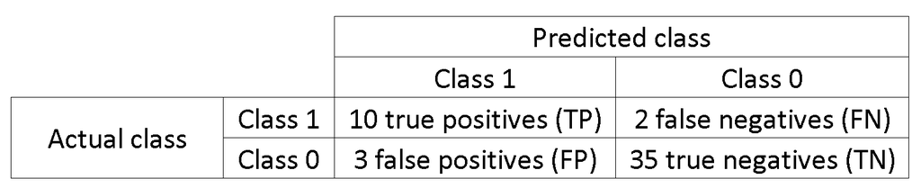

Confusion Matrix

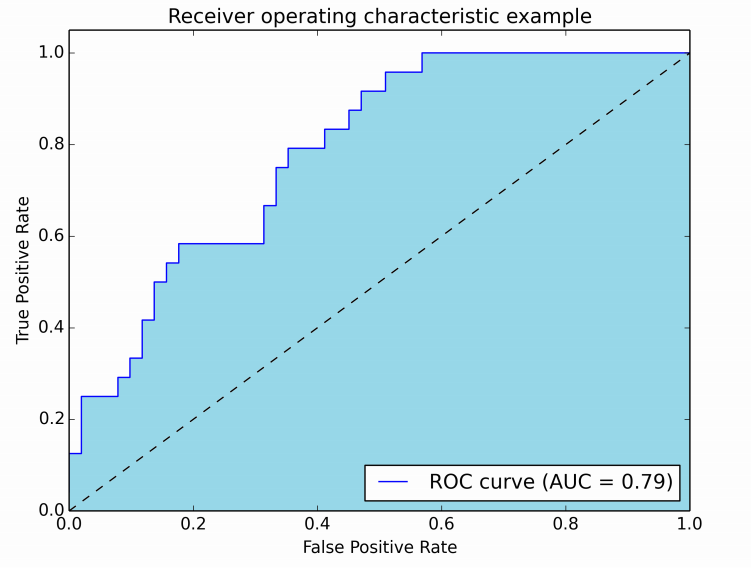

Area Under the Curve

```r
predictandCM<- function(amodel,data,modeltype)
{
  pred <-predict(amodel,data,type=modeltype)
  confusionMatrix(pred, reference=data$diabetes,positive = 'pos')
}
predictandCM(rtree_model,train.data,"class")
```

```
## Confusion Matrix and Statistics
##
##           Reference
## Prediction neg pos
##        neg 311  43
##        pos  39 145
##
##                Accuracy : 0.8476
##                  95% CI : (0.8144, 0.8769)
##     No Information Rate : 0.6506
##     P-Value [Acc > NIR] : <2e-16
##
##                   Kappa : 0.6631
##  Mcnemar's Test P-Value : 0.7404
##
##             Sensitivity : 0.7713
##             Specificity : 0.8886
##          Pos Pred Value : 0.7880
##          Neg Pred Value : 0.8785
##              Prevalence : 0.3494
##          Detection Rate : 0.2695
##    Detection Prevalence : 0.3420
##       Balanced Accuracy : 0.8299
##
##        'Positive' Class : pos
##
```

```r
predictandCM(rtree_model,test.data,"class")
```

```
## Confusion Matrix and Statistics
##
##           Reference
## Prediction neg pos
##        neg 116  17
##        pos  34  63
##
##                Accuracy : 0.7783
##                  95% CI : (0.719, 0.8302)
##     No Information Rate : 0.6522
##     P-Value [Acc > NIR] : 2.232e-05
##
##                   Kappa : 0.5343
##  Mcnemar's Test P-Value : 0.02506
##
##             Sensitivity : 0.7875
##             Specificity : 0.7733
##          Pos Pred Value : 0.6495
##          Neg Pred Value : 0.8722
##              Prevalence : 0.3478
##          Detection Rate : 0.2739
##    Detection Prevalence : 0.4217
##       Balanced Accuracy : 0.7804
##
##        'Positive' Class : pos
##
```

### Lets see if we can do better with caret

We will use the same train control parameters for all the models Use K-Fold Cross validation when parameter tuning to control over fitting

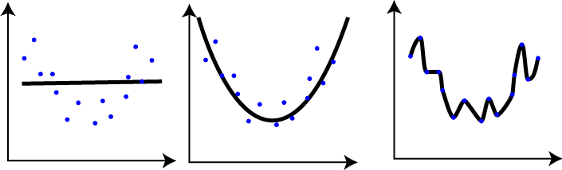

Overfitting

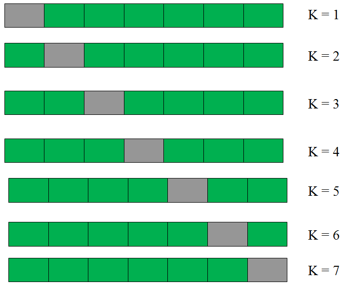

K Folds

```r
train.control <- trainControl(
                           method = "repeatedcv",
                           number = 10, ## 10-fold CV
                           repeats = 3,## repeated three times
                           # USE AUC
                           summaryFunction = twoClassSummary,
                           classProbs = TRUE
                           )
```

The tuneLength parameter is used to determine the total number of combinations that will be evaluated

```r
reset.seed()
system.time (rpartFit1 <- train(diabetes~., data=train.data,
                 method = "rpart2",
                 tuneLength = 6,
                 trControl = train.control,
                 metric = "ROC"
               ))
```

```
##    user  system elapsed
##    3.58    0.00    3.61
```

```r
rpartFit1
```

```
## CART
##
## 538 samples
##   8 predictor
##   2 classes: 'neg', 'pos'
##
## No pre-processing
## Resampling: Cross-Validated (10 fold, repeated 3 times)
## Summary of sample sizes: 485, 484, 484, 485, 484, 484, ...
## Resampling results across tuning parameters:
##
##   maxdepth  ROC        Sens       Spec
##    1        0.6926344  0.7714286  0.6138402
##    3        0.7302130  0.8352381  0.5603314
##    6        0.7423726  0.8390476  0.5498051
##   13        0.7437650  0.8285714  0.5552632
##   16        0.7416054  0.8266667  0.5551657
##   20        0.7407324  0.8266667  0.5533138
##
## ROC was used to select the optimal model using  the largest value.
## The final value used for the model was maxdepth = 13.
```

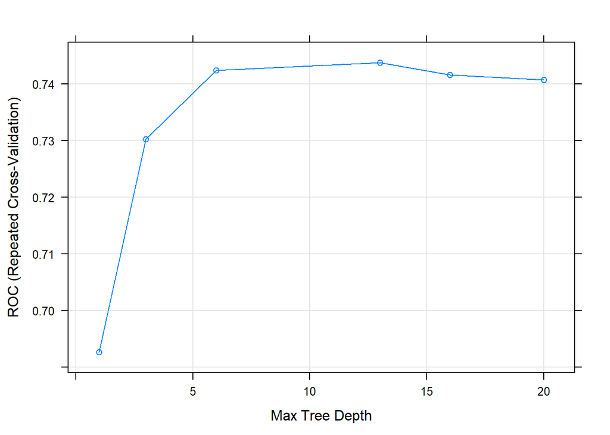

```r
plot(rpartFit1)
```

```r
rpartFit1$finalModel
```

```
## n= 538
##
## node), split, n, loss, yval, (yprob)
##       * denotes terminal node
##
##   1) root 538 188 neg (0.6505576 0.3494424)
##     2) glucose< 127.5 345  67 neg (0.8057971 0.1942029)
##       4) age< 28.5 187  16 neg (0.9144385 0.0855615) *
##       5) age>=28.5 158  51 neg (0.6772152 0.3227848)
##        10) mass< 26.35 32   2 neg (0.9375000 0.0625000) *
##        11) mass>=26.35 126  49 neg (0.6111111 0.3888889)
##          22) glucose< 99.5 42   8 neg (0.8095238 0.1904762) *
##          23) glucose>=99.5 84  41 neg (0.5119048 0.4880952)
##            46) pedigree< 0.2 17   3 neg (0.8235294 0.1764706) *
##            47) pedigree>=0.2 67  29 pos (0.4328358 0.5671642)
##              94) age>=53 8   1 neg (0.8750000 0.1250000) *
##              95) age< 53 59  22 pos (0.3728814 0.6271186)
##               190) triceps>=26.5 32  15 pos (0.4687500 0.5312500)
##                 380) mass< 32.15 7   1 neg (0.8571429 0.1428571) *
##                 381) mass>=32.15 25   9 pos (0.3600000 0.6400000) *
##               191) triceps< 26.5 27   7 pos (0.2592593 0.7407407) *
##     3) glucose>=127.5 193  72 pos (0.3730570 0.6269430)
##       6) glucose< 157.5 123  61 pos (0.4959350 0.5040650)
##        12) mass< 29.95 43  11 neg (0.7441860 0.2558140)
##          24) glucose< 145.5 33   5 neg (0.8484848 0.1515152) *
##          25) glucose>=145.5 10   4 pos (0.4000000 0.6000000) *
##        13) mass>=29.95 80  29 pos (0.3625000 0.6375000)
##          26) pressure>=61 70  29 pos (0.4142857 0.5857143)
##            52) age< 42 49  23 neg (0.5306122 0.4693878)
##             104) insulin>=192 14   2 neg (0.8571429 0.1428571) *
##             105) insulin< 192 35  14 pos (0.4000000 0.6000000)
##               210) mass< 41.35 27  13 pos (0.4814815 0.5185185)
##                 420) pedigree< 0.4875 14   5 neg (0.6428571 0.3571429) *
##                 421) pedigree>=0.4875 13   4 pos (0.3076923 0.6923077) *
##               211) mass>=41.35 8   1 pos (0.1250000 0.8750000) *
##            53) age>=42 21   3 pos (0.1428571 0.8571429) *
##          27) pressure< 61 10   0 pos (0.0000000 1.0000000) *
##       7) glucose>=157.5 70  11 pos (0.1571429 0.8428571) *
```

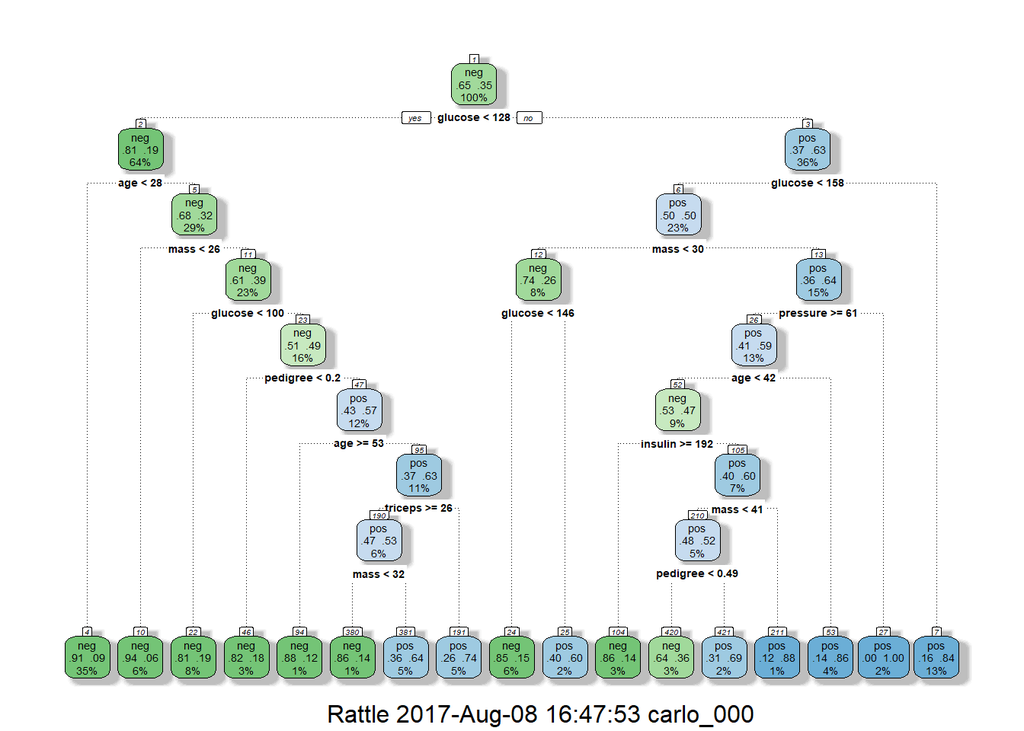

```r
fancyRpartPlot(rpartFit1$finalModel)
```

```r
predictandCM(rpartFit1$finalModel,train.data,"class")
```

```
## Confusion Matrix and Statistics
##
##           Reference
## Prediction neg pos
##        neg 311  43
##        pos  39 145
##
##                Accuracy : 0.8476
##                  95% CI : (0.8144, 0.8769)
##     No Information Rate : 0.6506
##     P-Value [Acc > NIR] : <2e-16
##
##                   Kappa : 0.6631
##  Mcnemar's Test P-Value : 0.7404
##
##             Sensitivity : 0.7713
##             Specificity : 0.8886
##          Pos Pred Value : 0.7880
##          Neg Pred Value : 0.8785
##              Prevalence : 0.3494
##          Detection Rate : 0.2695
##    Detection Prevalence : 0.3420
##       Balanced Accuracy : 0.8299
##
##        'Positive' Class : pos
##
```

```r
predictandCM(rpartFit1,test.data,"raw")
```

```
## Confusion Matrix and Statistics
##
##           Reference
## Prediction neg pos
##        neg 116  17
##        pos  34  63
##
##                Accuracy : 0.7783
##                  95% CI : (0.719, 0.8302)
##     No Information Rate : 0.6522
##     P-Value [Acc > NIR] : 2.232e-05
##
##                   Kappa : 0.5343
##  Mcnemar's Test P-Value : 0.02506
##
##             Sensitivity : 0.7875
##             Specificity : 0.7733
##          Pos Pred Value : 0.6495
##          Neg Pred Value : 0.8722
##              Prevalence : 0.3478
##          Detection Rate : 0.2739
##    Detection Prevalence : 0.4217
##       Balanced Accuracy : 0.7804
##
##        'Positive' Class : pos
##
```

## Grid Search

Set up caret to use a grid search for parameter tuning.

Manually configure Grid search

```r
reset.seed()

tune.gridcart <- expand.grid(maxdepth = 2:10)

system.time (rpartFit2 <- train(diabetes~., data=train.data,
                 method = "rpart2",
                 tuneGrid =tune.gridcart,
                 trControl = train.control,
                 metric = "ROC"
               ))
```

```
##    user  system elapsed
##    5.56    0.02    5.62
```

```r
rpartFit2
```

```
## CART
##
## 538 samples
##   8 predictor
##   2 classes: 'neg', 'pos'
##
## No pre-processing
## Resampling: Cross-Validated (10 fold, repeated 3 times)
## Summary of sample sizes: 485, 484, 484, 485, 484, 484, ...
## Resampling results across tuning parameters:
##
##   maxdepth  ROC        Sens       Spec
##    2        0.7269981  0.8361905  0.5461988
##    3        0.7302130  0.8352381  0.5603314
##    4        0.7371749  0.8552381  0.5268031
##    5        0.7350459  0.8485714  0.5268031
##    6        0.7423726  0.8390476  0.5498051
##    7        0.7462448  0.8380952  0.5624756
##    8        0.7483640  0.8380952  0.5588694
##    9        0.7498260  0.8247619  0.5676413
##   10        0.7407324  0.8266667  0.5533138
##
## ROC was used to select the optimal model using  the largest value.
## The final value used for the model was maxdepth = 9.
```

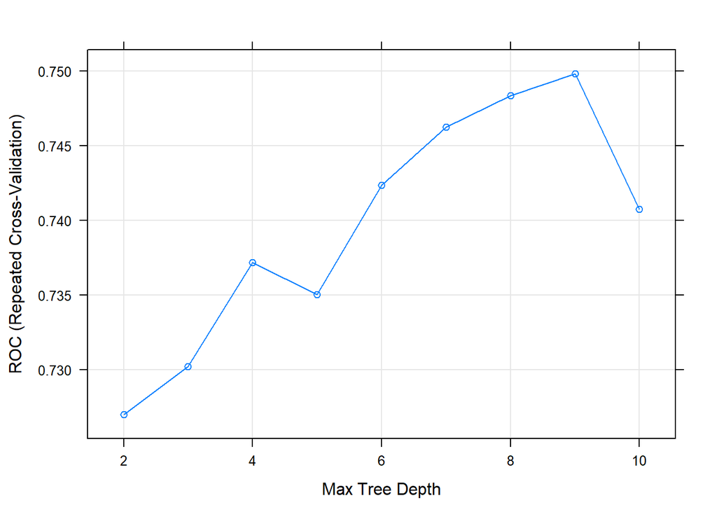

```r
plot(rpartFit2)
```

###

```r
predictandCM(rpartFit2$finalModel,train.data,"class")
```

```
## Confusion Matrix and Statistics
##
##           Reference
## Prediction neg pos
##        neg 311  43
##        pos  39 145
##
##                Accuracy : 0.8476
##                  95% CI : (0.8144, 0.8769)
##     No Information Rate : 0.6506
##     P-Value [Acc > NIR] : <2e-16
##
##                   Kappa : 0.6631
##  Mcnemar's Test P-Value : 0.7404
##
##             Sensitivity : 0.7713
##             Specificity : 0.8886
##          Pos Pred Value : 0.7880
##          Neg Pred Value : 0.8785
##              Prevalence : 0.3494
##          Detection Rate : 0.2695
##    Detection Prevalence : 0.3420
##       Balanced Accuracy : 0.8299
##
##        'Positive' Class : pos
##
```

```r
predictandCM(rpartFit2,test.data,"raw")
```

```
## Confusion Matrix and Statistics
##
##           Reference
## Prediction neg pos
##        neg 116  17
##        pos  34  63
##
##                Accuracy : 0.7783
##                  95% CI : (0.719, 0.8302)
##     No Information Rate : 0.6522
##     P-Value [Acc > NIR] : 2.232e-05
##
##                   Kappa : 0.5343
##  Mcnemar's Test P-Value : 0.02506
##
##             Sensitivity : 0.7875
##             Specificity : 0.7733
##          Pos Pred Value : 0.6495
##          Neg Pred Value : 0.8722
##              Prevalence : 0.3478
##          Detection Rate : 0.2739
##    Detection Prevalence : 0.4217
##       Balanced Accuracy : 0.7804
##
##        'Positive' Class : pos
##
```

## Tune a more complex model

xgbtree has a lot parameters that can be looked at

```r
reset.seed()

modelLookup("xgbTree")
```

```
##     model        parameter                          label forReg forClass
## 1 xgbTree          nrounds          # Boosting Iterations   TRUE     TRUE
## 2 xgbTree        max_depth                 Max Tree Depth   TRUE     TRUE
## 3 xgbTree              eta                      Shrinkage   TRUE     TRUE
## 4 xgbTree            gamma         Minimum Loss Reduction   TRUE     TRUE
## 5 xgbTree colsample_bytree     Subsample Ratio of Columns   TRUE     TRUE
## 6 xgbTree min_child_weight Minimum Sum of Instance Weight   TRUE     TRUE
## 7 xgbTree        subsample           Subsample Percentage   TRUE     TRUE
##   probModel
## 1      TRUE
## 2      TRUE
## 3      TRUE
## 4      TRUE
## 5      TRUE
## 6      TRUE
## 7      TRUE
```

```r
tune.gridxgb <- expand.grid(eta = c(0.05,0.3, 0.075), # 3
                      nrounds = c(50, 75, 100),  # 3
                      max_depth = 4:7,  # 4
                      min_child_weight = c(2.0, 2.25), #2
                      colsample_bytree = c(0.3, 0.4, 0.5), # 3
                      gamma = 0, #1
                      subsample = 1)  # 1
# 3*3*4*2*3*1*1 = 216
dim(tune.gridxgb)
```

```
## [1] 216   7
```

```r
system.time (gridxgFit1 <- train(diabetes~.,
              data=train.data,
              method = "xgbTree",
              tuneGrid =tune.gridxgb,
              trControl = train.control,
              metric = "ROC"
            ))
```

```
##    user  system elapsed
##  652.91  419.92  715.05
```

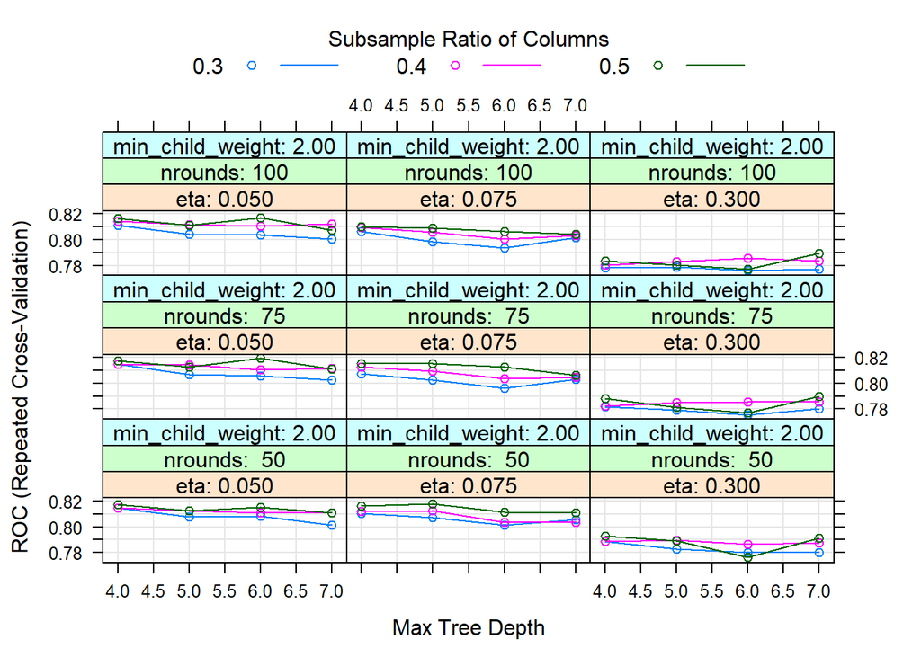

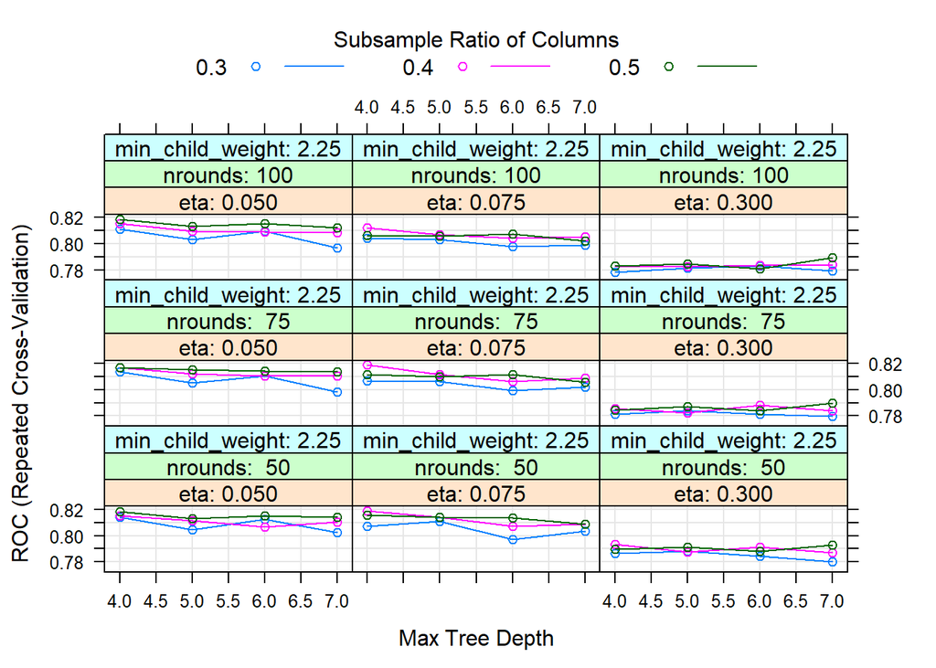

```r
plot(gridxgFit1)
```

```r
predictandCM(gridxgFit1,train.data,"raw")
```

```
## Confusion Matrix and Statistics
##
##           Reference
## Prediction neg pos
##        neg 344  26
##        pos   6 162
##
##                Accuracy : 0.9405
##                  95% CI : (0.9171, 0.959)
##     No Information Rate : 0.6506
##     P-Value [Acc > NIR] : < 2.2e-16
##
##                   Kappa : 0.8659
##  Mcnemar's Test P-Value : 0.0007829
##
##             Sensitivity : 0.8617
##             Specificity : 0.9829
##          Pos Pred Value : 0.9643
##          Neg Pred Value : 0.9297
##              Prevalence : 0.3494
##          Detection Rate : 0.3011
##    Detection Prevalence : 0.3123
##       Balanced Accuracy : 0.9223
##
##        'Positive' Class : pos
##
```

```r
predictandCM(gridxgFit1,test.data,"raw")
```

```
## Confusion Matrix and Statistics
##
##           Reference
## Prediction neg pos
##        neg 124  22
##        pos  26  58
##
##                Accuracy : 0.7913
##                  95% CI : (0.733, 0.8419)
##     No Information Rate : 0.6522
##     P-Value [Acc > NIR] : 2.878e-06
##
##                   Kappa : 0.5453
##  Mcnemar's Test P-Value : 0.665
##
##             Sensitivity : 0.7250
##             Specificity : 0.8267
##          Pos Pred Value : 0.6905
##          Neg Pred Value : 0.8493
##              Prevalence : 0.3478
##          Detection Rate : 0.2522
##    Detection Prevalence : 0.3652
##       Balanced Accuracy : 0.7758
##
##        'Positive' Class : pos
##
```

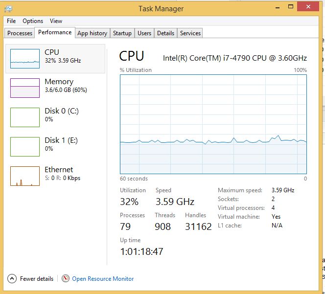

CPU usage while running grid

[figure not shown]

# Parallel

Use the doSNOW package to enable caret to train in parallel. doSNOW will work on Linux, Windows and Mac OS

Create a socket cluster using available number of cores

```r
#
library(doSNOW)
reset.seed()
numberofcores = detectCores()  # review what number of cores does for your environment

cl <- makeCluster(numberofcores, type = "SOCK")
# Register cluster so that caret will know to train in parallel.
registerDoSNOW(cl)

system.time (gridxgFit2 <- train(diabetes~.,
                  data=train.data,
                  method = "xgbTree",
                  tuneGrid =tune.gridxgb,
                  trControl = train.control,
                  metric = "ROC"
                ))
```

```
##    user  system elapsed
##    6.57    0.70  487.06
```

```r
stopCluster(cl)


#detach("package:doSNOW", unload=TRUE)

 #gridxgFit2
```

```r
predictandCM(gridxgFit2,train.data,"raw")
```

```
## Confusion Matrix and Statistics
##
##           Reference
## Prediction neg pos
##        neg 344  26
##        pos   6 162
##
##                Accuracy : 0.9405
##                  95% CI : (0.9171, 0.959)
##     No Information Rate : 0.6506
##     P-Value [Acc > NIR] : < 2.2e-16
##
##                   Kappa : 0.8659
##  Mcnemar's Test P-Value : 0.0007829
##
##             Sensitivity : 0.8617
##             Specificity : 0.9829
##          Pos Pred Value : 0.9643
##          Neg Pred Value : 0.9297
##              Prevalence : 0.3494
##          Detection Rate : 0.3011
##    Detection Prevalence : 0.3123
##       Balanced Accuracy : 0.9223
##
##        'Positive' Class : pos
##
```

```r
predictandCM(gridxgFit2,test.data,"raw")
```

```
## Confusion Matrix and Statistics
##
##           Reference
## Prediction neg pos
##        neg 124  22
##        pos  26  58
##
##                Accuracy : 0.7913
##                  95% CI : (0.733, 0.8419)
##     No Information Rate : 0.6522
##     P-Value [Acc > NIR] : 2.878e-06
##
##                   Kappa : 0.5453
##  Mcnemar's Test P-Value : 0.665
##
##             Sensitivity : 0.7250
##             Specificity : 0.8267
##          Pos Pred Value : 0.6905
##          Neg Pred Value : 0.8493
##              Prevalence : 0.3478
##          Detection Rate : 0.2522
##    Detection Prevalence : 0.3652
##       Balanced Accuracy : 0.7758
##
##        'Positive' Class : pos
##
```

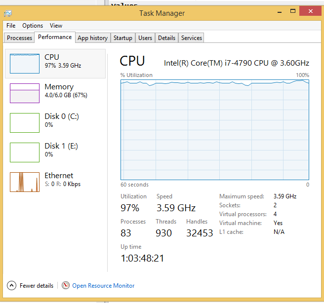

CPU usage while running grid in cluster

## References

- http://topepo.github.io/caret/index.html
- https://cran.r-project.org/web/packages/caret/index.html
- https://www.r-bloggers.com/a-quick-introduction-to-machine-learning-in-r-with-caret/
- http://www.dataschool.io/simple-guide-to-confusion-matrix-terminology/
- https://en.wikipedia.org/wiki/Cross-validation_(statistics)
- https://www.analyticsvidhya.com/blog/2016/02/7-important-model-evaluation-error-metrics/
- Python example using GridSearch and cross validation https://github.com/csantill/AustinSIGKDD-DecisionTrees/blob/master/notebooks/Decision%20Trees-diabetes.ipynb

```r
# unregister for each do parallel foreach
unregister <- function() {
  env <- foreach:::.foreachGlobals
  rm(list=ls(name=env), pos=env)
}
unregister()
```